# Drug vs Alcohol Deaths

Group 4

## Summary

The data seems to contradict what you read in the media:

A few things to note: Whites in the 50+ age group, may make up the largest part of the population. [kaggle: 2013 American Community Survey](https://www.kaggle.com/mchirico/d/census/2013-american-community-survey/population-by-age-and-race)

Also note the following two ICD10codes:

1. Icd10Code K703 Description: Alcoholic cirrhosis of liver.
2. The 2nd total highest Icd10Code is F102 Description: Mental and behavioural disorders due to use of alcohol: Dependence syndrome.

## Running the Analysis

Below taking a look at Alcohol vs. Drug deaths by age.

```r
library(ggplot2)
library(RSQLite)
library(scales)
library(dplyr)
library(tidyr)
library(knitr)

library(DT)

db <- dbConnect(dbDriver("SQLite"), "input/database.sqlite")

query <-paste("

select
    a.Age,a.Total Alcohol_Total ,a.White Alcohol_White,
    a.Black Alcohol_Black,a.All_Other  Alcohol_Other,
    g.Total Drug_Total,
    g.White Drug_White,g.Black Drug_Black,g.All_Other Drug_Other
from (
  select
      Age,count(*) Total ,sum(Race == 1) as White,
      sum(Race == 2) as Black, sum(Race != 1 and Race != 2) All_Other
   from DeathRecords d,
     (
     select
       distinct e.DeathRecordId as id
       from
         EntityAxisConditions e,
         (
            select *
            from Icd10Code where Description like '%alcohol%'

         ) as c
        where e.Icd10Code = c.code) as f
    where d.id = f.id and AgeType = 1 and Age < 500
    group by Age
    ) as a, -- Alcohol

(
 select
     Age,count(*) Total ,sum(Race == 1) as White,
     sum(Race == 2) as Black, sum(Race != 1 and Race != 2) All_Other
   from DeathRecords d,
       (select
           distinct e.DeathRecordId as id
           from
              EntityAxisConditions e,
              (
 -- Every Firearm discharge, except Legal intervention
        select
           Code,Description
           from Icd10Code
           where description like '%drug%'
              ) as c
        where e.Icd10Code = c.code) as f
    where d.id = f.id and AgeType = 1 and Age < 500
    group by Age
    ) as g
     where g.Age = a.Age
     -- End of SQL
")

allAlcoholDrug <- dbGetQuery(db, query)

# -- Just Look at Totals
data <- select(allAlcoholDrug, Alcohol_Total,Drug_Total,Age) %>%
          gather(Group,Deaths,-Age)

g <- ggplot(dat = data,
       aes(x=Age, y=Deaths)) +
      geom_line(aes(colour=Group, group=Group)) +
      geom_point(aes(colour=Group, shape=Group, group=Group), size=1)+
  ggtitle("Drugs vs. Alcohol Deaths\nby Age")
```

### Graph of Drugs vs. Alcohol

The graph below is interesting. Note the 2nd jump in deaths, after age 50.

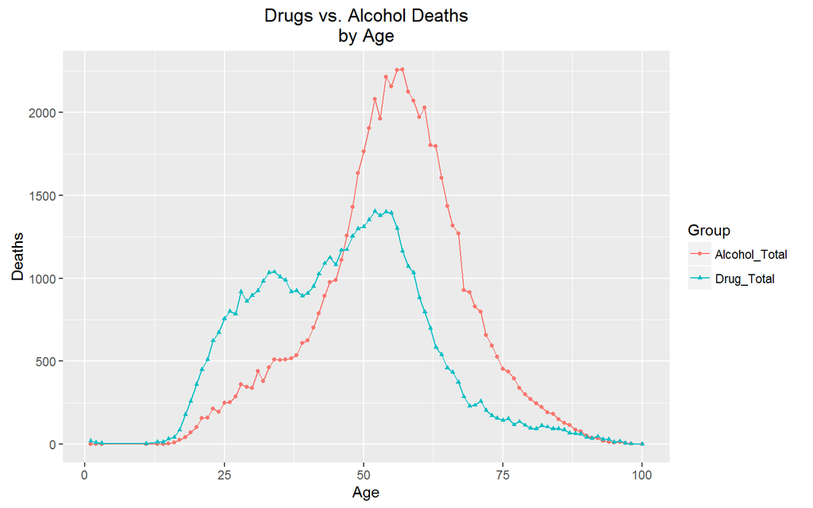

```r
# Show plot
g
```

### Race

Let’s further subdivide this by race. And this is where it starts to get interesting.

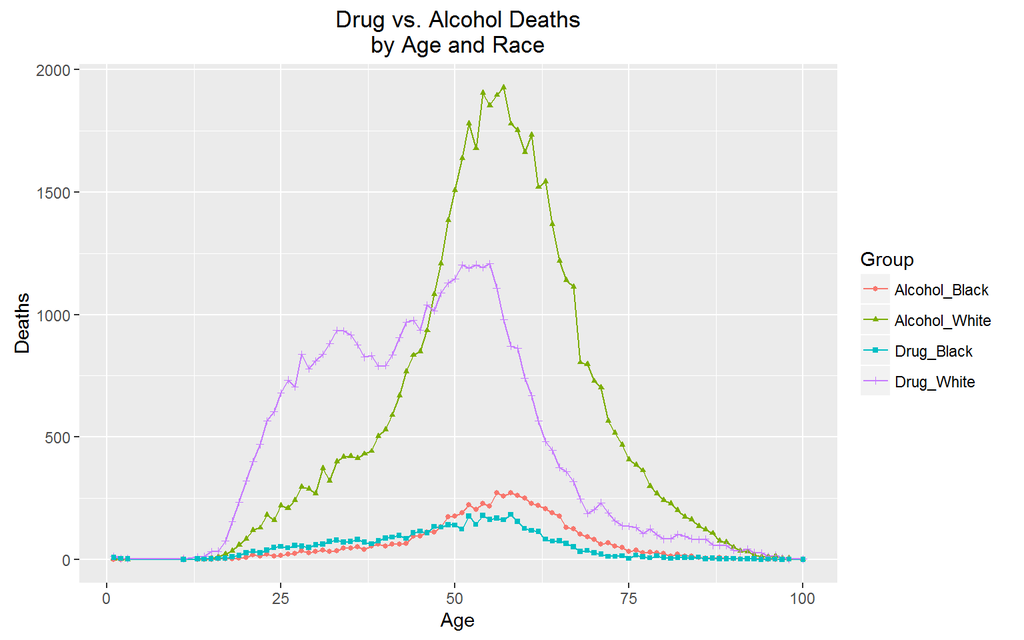

```r
# Let's see where the jump is coming from.

data <- select(allAlcoholDrug, Alcohol_White, Alcohol_Black,
               Drug_White, Drug_Black,Age) %>%
               gather(Group,Deaths,-Age)

ggplot(dat = data,
       aes(x=Age, y=Deaths)) +
      geom_line(aes(color=Group, group=Group)) +
      geom_point(aes(color=Group, shape=Group, group=Group), size=1)+
  ggtitle("Drug vs. Alcohol Deaths\nby Age and Race")
```

### Close Look at the Numbers

Let’s take a close look at the numbers. It might help to see this in table form.

```r
# Look at the numbers
datatable(allAlcoholDrug, class = 'compact')
```

|  | Age | Alcohol_Total | Alcohol_White | Alcohol_Black | Alcohol_Other | Drug_Total | Drug_White | Drug_Black | Drug_Other |
| --- | --- | --- | --- | --- | --- | --- | --- | --- | --- |
| 1 | 1 | 1 | 1 | 0 | 0 | 20 | 12 | 8 | 0 |
| 2 | 2 | 1 | 1 | 0 | 0 | 9 | 4 | 4 | 1 |
| 3 | 3 | 1 | 0 | 1 | 0 | 6 | 3 | 3 | 0 |
| 4 | 11 | 1 | 0 | 1 | 0 | 3 | 3 | 0 | 0 |
| 5 | 13 | 1 | 1 | 0 | 0 | 12 | 10 | 2 | 0 |
| 6 | 14 | 1 | 1 | 0 | 0 | 14 | 13 | 1 | 0 |
| 7 | 15 | 4 | 4 | 0 | 0 | 33 | 31 | 2 | 0 |
| 8 | 16 | 11 | 10 | 1 | 0 | 43 | 33 | 4 | 6 |
| 9 | 17 | 26 | 21 | 1 | 4 | 85 | 76 | 5 | 4 |
| 10 | 18 | 42 | 35 | 3 | 4 | 178 | 156 | 10 | 12 |

[output cut: 81 more lines]

```r
db <- dbConnect(dbDriver("SQLite"), "input/database.sqlite")

query <-paste("

select *

from (

select Icd10Code,count(*) count from

( -- Put the whole previous query block in here

 select distinct d.id
   from DeathRecords d,
     (select distinct e.DeathRecordId as id from
     EntityAxisConditions e,
     (

     -- Every Firearm discharge, except Legal intervention
    select Code,Description from Icd10Code
     where description like '%alcohol%'

   ) as c
  where e.Icd10Code = c.code) as f
  where d.id = f.id and AgeType = 1

  -- End of big query block
) as s

,DeathRecords d
where s.id=d.id
group by Icd10Code order by count desc


) as a,
Icd10Code b where
a.Icd10Code = b.code limit 10

")

vData <- dbGetQuery(db, query)
```

### Top Icd10Codes

See the table below for an explaination of the top ICD10codes. Please note the top 2 codes, and the count (total number of deaths) for each entry.

The top code K703, list ‘Alcoholic cirrhosis of liver’.

```r
# This might explain why the results seem odd.
kable(vData)
```

| Icd10Code | count | Code | Description |
| --- | --- | --- | --- |
| K703 | 13887 | K703 | Alcoholic cirrhosis of liver |
| F102 | 4434 | F102 | Mental and behavioural disorders due to use of alcohol: Dependence syndrome |
| X42 | 3109 | X42 | Accidental poisoning by and exposure to narcotics and psychodysleptics [hallucinogens], not elsewhere classified |
| F101 | 2757 | F101 | Mental and behavioural disorders due to use of alcohol: Harmful use |
| K709 | 2583 | K709 | Alcoholic liver disease, unspecified |
| X44 | 2457 | X44 | Accidental poisoning by and exposure to other and unspecified drugs, medicaments and biological substances |
| X45 | 2310 | X45 | Accidental poisoning by and exposure to alcohol |
| I250 | 1888 | I250 | Atherosclerotic cardiovascular disease, so described |
| I119 | 1398 | I119 | Hypertensive heart disease without (congestive) heart failure |
| K704 | 1391 | K704 | Alcoholic hepatic failure |

## Explaination:

```r
db <- dbConnect(dbDriver("SQLite"), "input/database.sqlite")

query <-paste("


select Age,count(*) Total ,sum(Race == 1) as White,
  sum(Race == 2) as Black, sum(Race != 1 and Race != 2) All_Other,
  sum(Race == 1 and Icd10Code == 'K703')  W_K703,
  sum(Race == 2 and Icd10Code == 'K703')  B_K703,

  sum(Race == 1 and Icd10Code == 'F102')  W_F102,
  sum(Race == 2 and Icd10Code == 'F102')  B_F102,

  sum(Race == 1 and Icd10Code == 'X42')  W_X42,
  sum(Race == 2 and Icd10Code == 'X42')  B_X42,

  sum(Race == 1 and Icd10Code == 'F101')  W_F101,
  sum(Race == 2 and Icd10Code == 'F101')  B_F101,

  sum(Race == 1 and Icd10Code == 'K709')  W_K709,
  sum(Race == 2 and Icd10Code == 'K709')  B_K709,

  sum(Race == 1 and Icd10Code == 'X44')  W_X44,
  sum(Race == 2 and Icd10Code == 'X44')  B_X44





 from DeathRecords d,
   (select distinct e.DeathRecordId as id from
   EntityAxisConditions e,
   (

   select Code,Description from Icd10Code
   where description like '%alcohol%'



   ) as c
  where e.Icd10Code = c.code) as f
  where d.id = f.id and AgeType = 1 and Age < 500
 group by Age;

")

v2Data <- dbGetQuery(db, query)

data <- select(v2Data, W_X44,B_X44,
               Age) %>%
  gather(Group,Total,-Age)

g <- ggplot(dat = data,
       aes(x=Age, y=Total)) +
      geom_line(aes(color=Group, group=Group)) +
      geom_point(aes(color=Group, shape=Group, group=Group), size=1)+
  ggtitle("K703 - Alcoholic cirrhosis of liver \nby Age")
```

[figure not shown]

```r
# Display graph
g
```

### Listing the Table

```r
# Here's more detail
datatable(v2Data, class = 'compact')
```

|  | Age | Total | White | Black | All_Other | W_K703 | B_K703 | W_F102 | B_F102 | W_X42 | B_X42 | W_F101 | B_F101 | W_K709 | B_K709 | W_X44 | B_X44 |
| --- | --- | --- | --- | --- | --- | --- | --- | --- | --- | --- | --- | --- | --- | --- | --- | --- | --- |
| 1 | 1 | 1 | 1 | 0 | 0 | 0 | 0 | 0 | 0 | 0 | 0 | 0 | 0 | 0 | 0 | 0 | 0 |
| 2 | 2 | 1 | 1 | 0 | 0 | 0 | 0 | 0 | 0 | 0 | 0 | 0 | 0 | 0 | 0 | 0 | 0 |
| 3 | 3 | 1 | 0 | 1 | 0 | 0 | 0 | 0 | 0 | 0 | 0 | 0 | 0 | 0 | 0 | 0 | 0 |
| 4 | 11 | 1 | 0 | 1 | 0 | 0 | 0 | 0 | 0 | 0 | 0 | 0 | 0 | 0 | 0 | 0 | 0 |
| 5 | 13 | 1 | 1 | 0 | 0 | 0 | 0 | 0 | 0 | 0 | 0 | 0 | 0 | 0 | 0 | 0 | 0 |
| 6 | 14 | 1 | 1 | 0 | 0 | 0 | 0 | 0 | 0 | 0 | 0 | 0 | 0 | 0 | 0 | 0 | 0 |
| 7 | 15 | 4 | 4 | 0 | 0 | 0 | 0 | 0 | 0 | 1 | 0 | 0 | 0 | 0 | 0 | 0 | 0 |
| 8 | 16 | 11 | 10 | 1 | 0 | 0 | 0 | 0 | 0 | 0 | 0 | 0 | 0 | 0 | 0 | 2 | 0 |
| 9 | 17 | 26 | 21 | 1 | 4 | 0 | 0 | 0 | 0 | 0 | 0 | 0 | 0 | 0 | 0 | 3 | 0 |
| 10 | 18 | 42 | 35 | 3 | 4 | 0 | 0 | 0 | 0 | 2 | 0 | 0 | 0 | 0 | 0 | 4 | 0 |

[output cut: 83 more lines]